# Human-Activity-Recognition Modelling

spemurphy

2024-11-30

# Introduction

The aim of this analysis is to attempt to build a machine learning model that is able to predict how well someone performs an exercise based on the information provided by their human-activity-recognition monitoring device (fitness wearable). The project begins with loading and processing the data to then explore and understand the class of exercise performance themself and the different types of wearables available, as well as their relationships to eachother. Finally, models are chosen, trained and then tested on multiple occassions to understand the nuances of model performance and accuracy, and how robust they are on unseen data.

# Data Loading

## Loading data

```r
getwd()
```

```
## [1] "/Users/seanmurphy/Desktop/DS_coursera/Human-Activity-Recognition-Modelling"
```

```r
if (!file.exists("data")){dir.create("data")}
trainUrl <- "https://d396qusza40orc.cloudfront.net/predmachlearn/pml-training.csv"
testUrl <- "https://d396qusza40orc.cloudfront.net/predmachlearn/pml-testing.csv"
download.file(trainUrl, destfile="./data/train.csv", method="curl")
download.file(testUrl, destfile="./data/test.csv", method="curl")
list.files("./data")
```

```
## [1] "test.csv"  "train.csv"
```

```r
dateDownloaded <- date()
dateDownloaded
```

```
## [1] "Sat Nov 30 07:14:05 2024"
```

## Reading data and loading libraries

```r
library(ggplot2)
library(readr)
library(caret)
library(Hmisc)
library(e1071)
library(dplyr)
library(Metrics)
library(patchwork)
trainData <- read.csv("./data/train.csv")
testData <- read.csv("./data/test.csv")
head(trainData)
```

[output not shown]

```r
levels(trainData$classe)
```

[output not shown]

```r
trainData$classe <- as.factor(trainData$classe)
dim(trainData) #19622, 160
```

```
## [1] 19622   160
```

```r
table(trainData$classe) #data is imbalanced toward classe A and slightly more for classe B
```

```
##
##    A    B    C    D    E
## 5580 3797 3422 3216 3607
```

```r
#Fixing imbalance
set.seed(123)
#Imbalance ratio
imbalanceRatio <- table(trainData$classe)["A"] / mean(table(trainData$classe)[c("B", "C", "D", "E")])
imbalanceRatio
```

```
##        A
## 1.589517
```

```r
class_weights <- c(
  "A" = 1.589517,  # This class is 1.589517 times larger than the average
  "B" = 1,         # Set weight of 1 for the average classes
  "C" = 1,
  "D" = 1,
  "E" = 1
)
```

## Data Splitting

Data is split into train set to build the model, and two subsequent validation and test sets to understand model performance and test accuracy.

```r
inBuild <- createDataPartition(y=trainData$classe,
                               p=0.7, list=FALSE)
validation <- trainData[-inBuild, ]; buildData <- trainData[inBuild,]

inTrain <- createDataPartition(y=buildData$classe,
                               p=0.7, list=FALSE)
training <- buildData[inTrain, ]; testing <- buildData[-inTrain, ]

dim(training) # 9619, 160
```

```
## [1] 9619  160
```

```r
dim(testing) # 4118, 160
```

```
## [1] 4118  160
```

```r
dim(validation) # 5885, 160
```

```
## [1] 5885  160
```

# Exploratory Data Analysis

## BELT

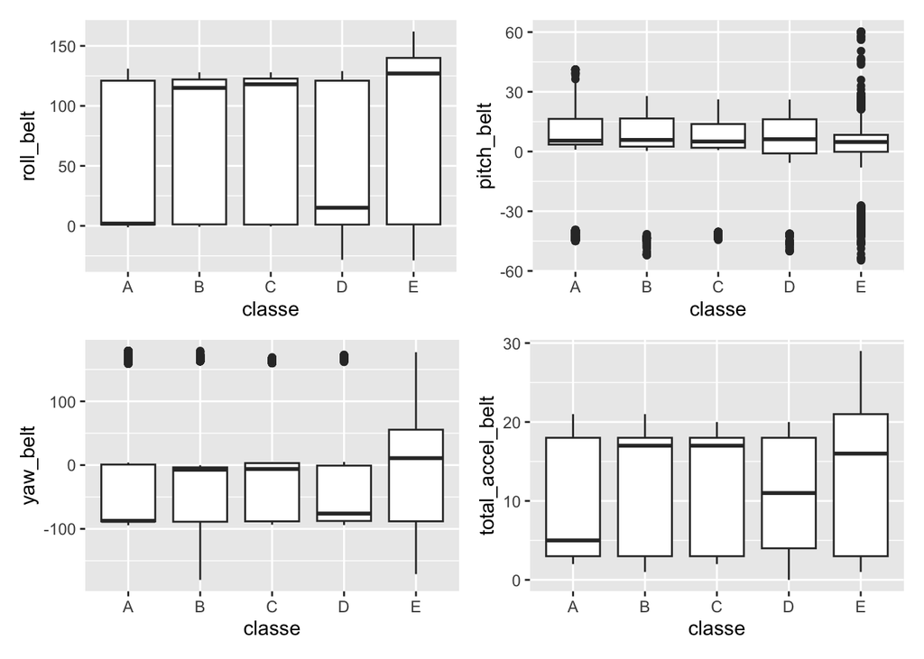

```r
p2 <- qplot(classe, roll_belt, data=training,
            geom=c("boxplot"))
p3 <- qplot(classe, pitch_belt, data=training,
            geom=c("boxplot"))
p4 <- qplot(classe, yaw_belt, data=training,
            geom=c("boxplot"))
p5 <- qplot(classe, total_accel_belt, data=training,
            geom=c("boxplot"))
(p2 | p3) / (p4 | p5)
```

For pitch_belt, the medians of classe A:E appear around zero. However, roll_belt, yaw_belt and total_accelt_belt medians increase as movement form goes from classe A to classe E. This indicates that as roll_belt, yaw_belt and total_accel_belt increase, movement form decreases, except for classe D, which may be an outlier.

## ARM

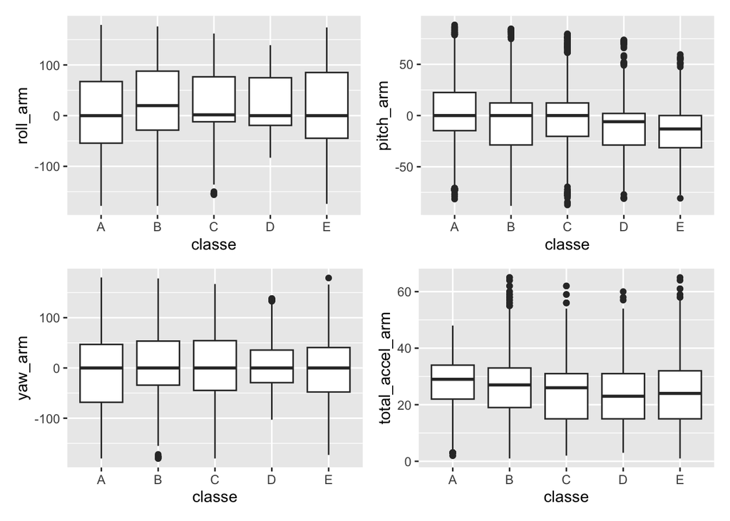

```r
a1 <- qplot(classe, roll_arm, data=training,
            geom=c("boxplot"))
a2 <- qplot(classe, pitch_arm, data=training,
            geom=c("boxplot"))
a3 <- qplot(classe, yaw_arm, data=training,
            geom=c("boxplot"))
a4 <- qplot(classe, total_accel_arm, data=training,
            geom=c("boxplot"))
(a1 | a2) / (a3 | a4)
```

Three of the four charts above highlight differences between classe: A and the remaining classes. Pitch_arm and total_accel_arm show slight differences between levels for classe: A to classe: E, where this is a small downward trend. This suggests that there when these numbers are lower, exercise performance decreases.

##FOREARM

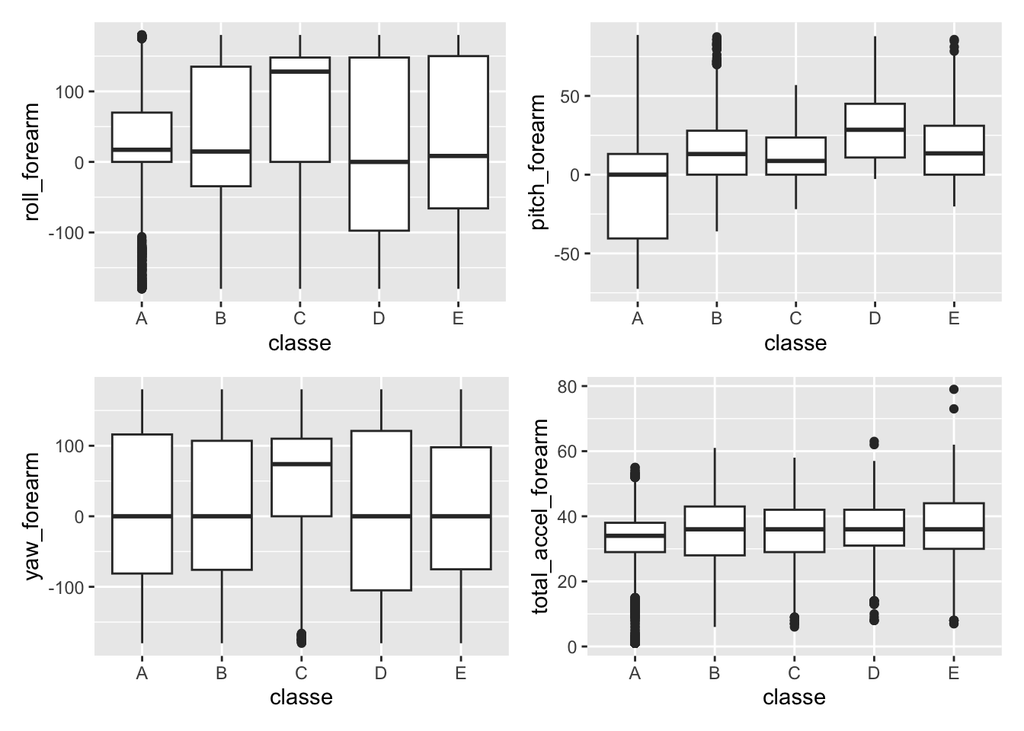

```r
f1 <- qplot(classe, roll_forearm, data=training,
            geom=c("boxplot"))
f2 <- qplot(classe, pitch_forearm, data=training,
            geom=c("boxplot"))
f3 <- qplot(classe, yaw_forearm, data=training,
            geom=c("boxplot"))
f4 <- qplot(classe, total_accel_forearm, data=training,
            geom=c("boxplot"))
(f1 | f2) / (f3 | f4)
```

Again, pitch_forearm highlights a small upward trend from classe: A to classe: E, indicating that exercise worsens as pitch_forearm increases. Total_accel_forearm on the other hand shows differences between the classes, if only slight, that classe: B to classe: E are different from classe: A.

##DUMBELL

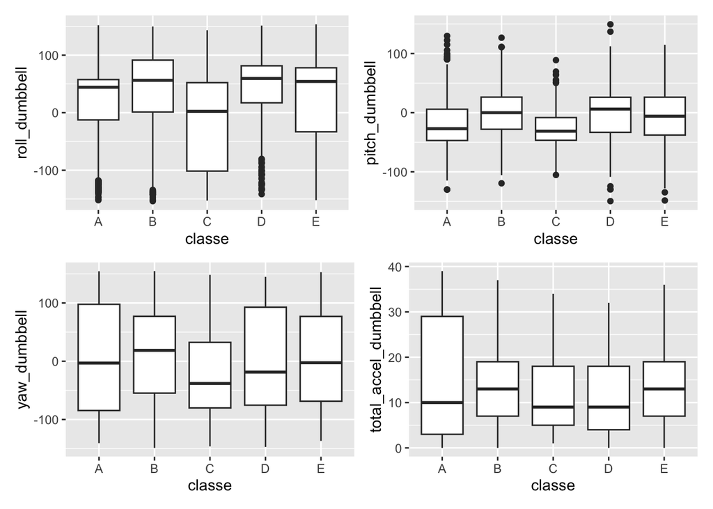

```r
d1 <- qplot(classe, roll_dumbbell, data=training,
            geom=c("boxplot"))
d2 <- qplot(classe, pitch_dumbbell, data=training,
            geom=c("boxplot"))
d3 <- qplot(classe, yaw_dumbbell, data=training,
            geom=c("boxplot"))
d4 <- qplot(classe, total_accel_dumbbell, data=training,
            geom=c("boxplot"))
(d1 | d2) / (d3 | d4)
```